# Peer Assessment 1

gadfly1974

Sunday, July 20, 2014

### Loading and Preprocessing the data

Load data from ZIP file on local hard drive

```r
activity <- read.csv("C:/Users/Andy/Dropbox/DataScienceCoursera/activity.csv")
```

Transform data to a new data frame with timestamp column, class “POSIXct” “POSIXt”

```r
activity$interval <- formatC(activity$interval, width = 4, format = "d", flag = "0")
activitydatetime <- transform(activity, timestamp=as.POSIXct(paste(date, interval), format="%Y-%m-%d %H%M"))
```

Convert data frame to data table

```r
library("data.table", lib.loc="C:/Users/Andy/Dropbox/R/R/R-3.0.3/library")

activity.dt <- as.data.table(activitydatetime)
rm(activity, activitydatetime)
```

Omit NA observations

```r
activityna.dt <- na.omit(activity.dt)
```

### What is mean total number of steps taken per day?

Calculate total steps per day

```r
totalsteps <- activityna.dt[,sum(steps),by="date"]
```

Plot histogram of data without NAs

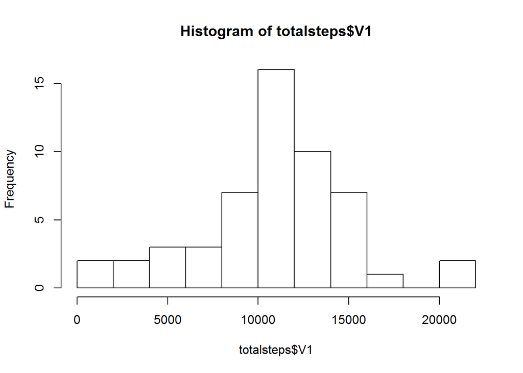

Find the mean and median by date

```r
meanbydate <- activityna.dt[,mean(steps),by="date"]
meanbydate
```

```
##           date      V1
##  1: 2012-10-02  0.4375
##  2: 2012-10-03 39.4167
##  3: 2012-10-04 42.0694
##  4: 2012-10-05 46.1597
##  5: 2012-10-06 53.5417
##  6: 2012-10-07 38.2465
##  7: 2012-10-09 44.4826
##  8: 2012-10-10 34.3750
##  9: 2012-10-11 35.7778
## 10: 2012-10-12 60.3542
## 11: 2012-10-13 43.1458
## 12: 2012-10-14 52.4236
## 13: 2012-10-15 35.2049
## 14: 2012-10-16 52.3750
```

[output cut: 40 more lines]

```r
medianbydate <- activityna.dt[,median(steps),by="date"]
medianbydate
```

```
##           date V1
##  1: 2012-10-02  0
##  2: 2012-10-03  0
##  3: 2012-10-04  0
##  4: 2012-10-05  0
##  5: 2012-10-06  0
##  6: 2012-10-07  0
##  7: 2012-10-09  0
##  8: 2012-10-10  0
##  9: 2012-10-11  0
## 10: 2012-10-12  0
## 11: 2012-10-13  0
## 12: 2012-10-14  0
## 13: 2012-10-15  0
## 14: 2012-10-16  0
```

[output cut: 40 more lines]

### What is the average daily activity pattern?

Calculate time series averages

```r
meanbyinterval <- activityna.dt[,mean(steps),by="interval"]
```

Create a time series plot. Midnight = 0 and 12:05am = 1. 11:55pm = 288. Time 100 represents 100 times 5 or 500 minutes after midnight, 8:20am.

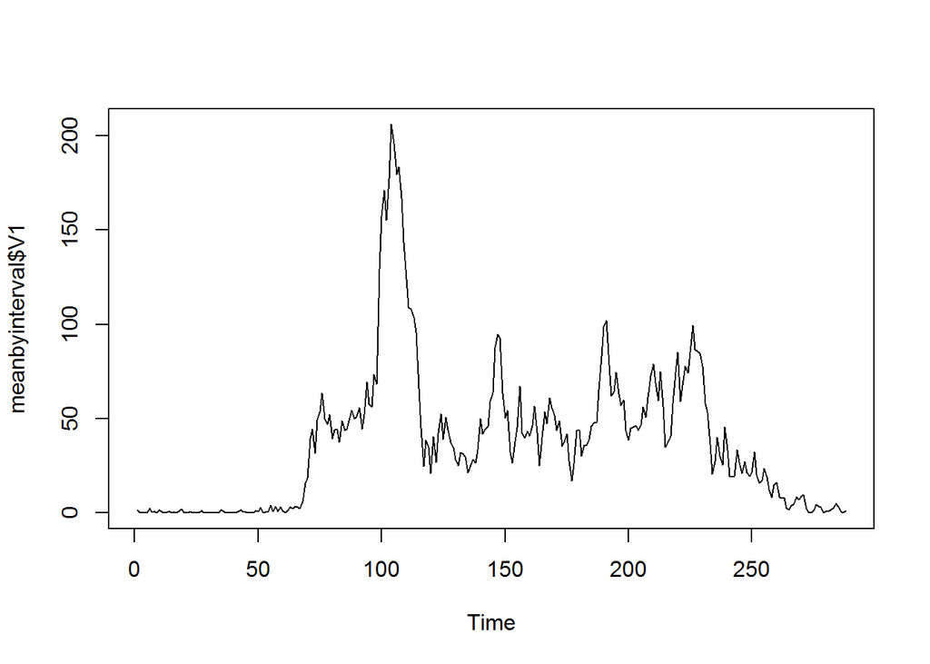

It looks like the subject is typically asleep from time 0 (midnight) to time 70*5, 350 minutes after midnight, or 5:50 am. Perhaps the subject has an alarm set for 6am each morning.

Find the maximum interval

```r
which.max(meanbyinterval$V1)
```

```
## [1] 104
```

```r
meanbyinterval$interval[104]
```

```
## [1] "0835"
```

This shows a time of 8:35AM

Next, calculate number of missing values in original dataset

```r
colSums(is.na(activity.dt))
```

```
##     steps      date  interval timestamp
##      2304         0         0         0
```

There are 2304 NAs in the original dataset.

### Imputing missing values

Next, I created a large list of intervals for checking NA values by interval

```r
intervals61 <- rep_len(meanbyinterval$interval, 17568)
```

And also a large list of interval means for checking NA values by interval

```r
intervalmean61 <- rep_len(meanbyinterval$V1, 17568)
```

Then, I created a dataframe for checking against the NAs in original data set

```r
meanbyinterval61 <- cbind(intervals61, intervalmean61)
## This creates a matrix, convert to data frame
meanbyinterval61.df <- as.data.frame(meanbyinterval61)
## Then change the intervalmean column to numeric from character
meanbyinterval61.df$intervalmean61 <- as.numeric(as.character(meanbyinterval61.df$intervalmean61))
```

I needed significant help to complete the next step of my analysis. https://class.coursera.org/repdata-004/forum/thread?thread_id=82 and http://stackoverflow.com/questions/24847299/using-ifelse-to-replace-nas-in-one-data-frame-by-referencing-another-data-fram helped me figure out how to impute mean averages by interval to the original data set for NAs only

```r
activity.dt$steps <- ifelse(is.na(activity.dt$steps) == TRUE, meanbyinterval61.df$intervalmean61
                            [meanbyinterval61.df$intervals61 %in% activity.dt$interval],
                            activity.dt$steps)
```

```r
totalsteps <- activityna.dt[,sum(steps),by="date"]
```

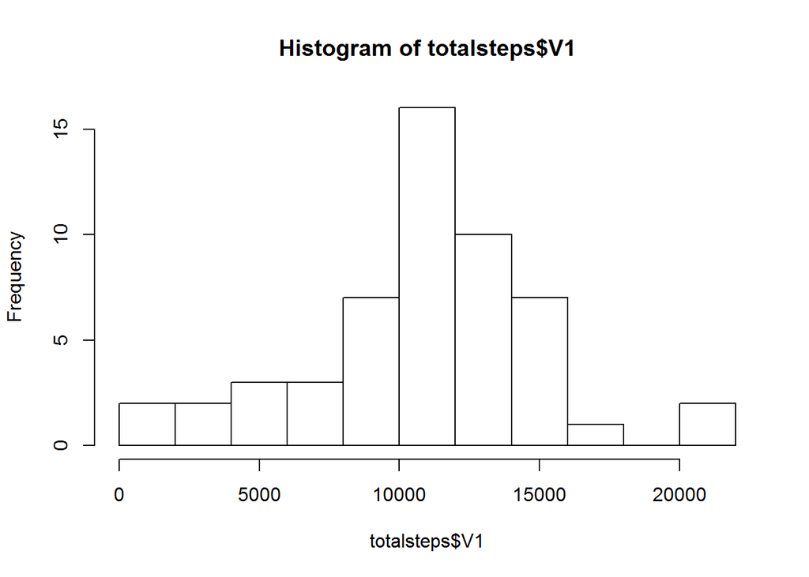

```r
meanbydate <- activityna.dt[,mean(steps),by="date"]
meanbydate
```

```
##           date      V1
##  1: 2012-10-02  0.4375
##  2: 2012-10-03 39.4167
##  3: 2012-10-04 42.0694
##  4: 2012-10-05 46.1597
##  5: 2012-10-06 53.5417
##  6: 2012-10-07 38.2465
##  7: 2012-10-09 44.4826
##  8: 2012-10-10 34.3750
##  9: 2012-10-11 35.7778
## 10: 2012-10-12 60.3542
## 11: 2012-10-13 43.1458
## 12: 2012-10-14 52.4236
## 13: 2012-10-15 35.2049
## 14: 2012-10-16 52.3750
```

[output cut: 40 more lines]

```r
medianbydate <- activityna.dt[,median(steps),by="date"]
medianbydate
```

```
##           date V1
##  1: 2012-10-02  0
##  2: 2012-10-03  0
##  3: 2012-10-04  0
##  4: 2012-10-05  0
##  5: 2012-10-06  0
##  6: 2012-10-07  0
##  7: 2012-10-09  0
##  8: 2012-10-10  0
##  9: 2012-10-11  0
## 10: 2012-10-12  0
## 11: 2012-10-13  0
## 12: 2012-10-14  0
## 13: 2012-10-15  0
## 14: 2012-10-16  0
```

[output cut: 40 more lines]

### Are there differences in activity patterns between weekdays and weekends?

To create the final panel plot, I converted the day of the week for each observation to a factor

```r
weekdayweekendfactor <- strftime(activity.dt$date, "%w")
## Weekday as a decimal number (0-6, Sunday is 0)
```

Then I changed each factor from 0 or 6 to “weekend”, 1:5 to “weekday”

```r
weekdayweekendfactor <- gsub("1", "weekday", weekdayweekendfactor)
weekdayweekendfactor <- gsub("2", "weekday", weekdayweekendfactor)
weekdayweekendfactor <- gsub("3", "weekday", weekdayweekendfactor)
weekdayweekendfactor <- gsub("4", "weekday", weekdayweekendfactor)
weekdayweekendfactor <- gsub("5", "weekday", weekdayweekendfactor)
weekdayweekendfactor <- gsub("6", "weekend", weekdayweekendfactor)
weekdayweekendfactor <- gsub("0", "weekend", weekdayweekendfactor)
```

Next, I activated the lattice package and attempted to reproduce the required diagram

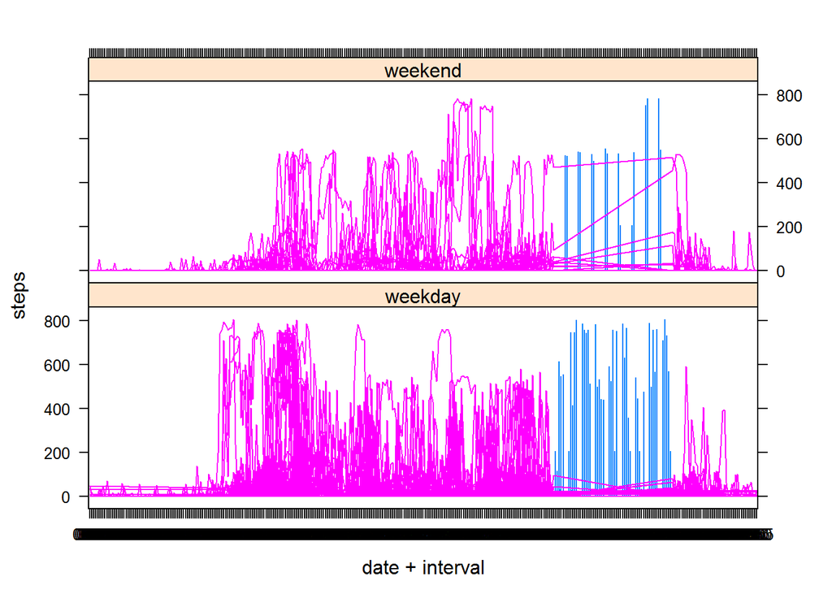

```r
library("lattice", lib.loc="C:/Users/Andy/Dropbox/R/R/R-3.0.3/library")
xyplot(steps ~ date + interval | weekdayweekendfactor, data = activity.dt, type = "l", layout = c(1, 2))
```

### Request for feedback

As you can see, I created a plot of every data point, not a comparison between weekend and weekday average steps by time interval. Please give me feedback in your comments if you see a solution to my mistake. Thank you.